# STAA57 - Worksheet 18

Name: , ID#:

Due

**Goal**: Practice multi-feature classification with logistic regression and classification trees.

You will work with the following toy data.

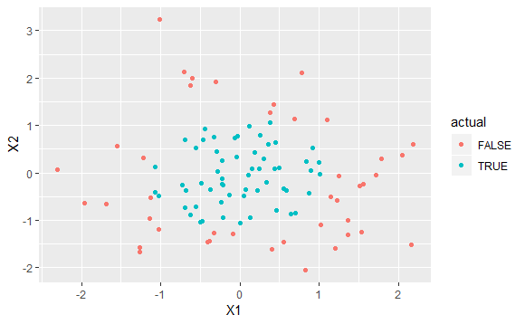

```r
set.seed(123)
toy = tibble( X1 = rnorm(100), X2 = rnorm(100) ) %>%
  mutate( actual = factor( X1^2 + X2^2 < 1.4 ) )
ggplot( toy, aes(x = X1, y = X2, col = actual )) + geom_point()
```

1. Fit a logistic regression model to the toy data and report the confusion matrix.
2. Plot the decision boundary of your linear classifier from the previous part. Use `geom_abline()`, with *intercept* and *slope* arguments given by the following representation of the linear decision boundary
   $$\beta_0 + \beta_1 x_1 + \beta_2 x_2 = 0 \Rightarrow x_2 = -\frac{\beta_0}{\beta_2} - \frac{\beta_1}{\beta_2} x_1$$
3. The following code fits a classification tree to the data.

```r
library(rpart)
rpart_out = rpart( actual ~ X1 + X2, data = toy, method = "class" )
```

Report the model’s confusion matrix.

4. Plot the decision tree from the previous part.
5. Find the predicted class for the point $(X1=.5, X2=1)$.
6. Which of the following plots, if any, represents your decision tree?

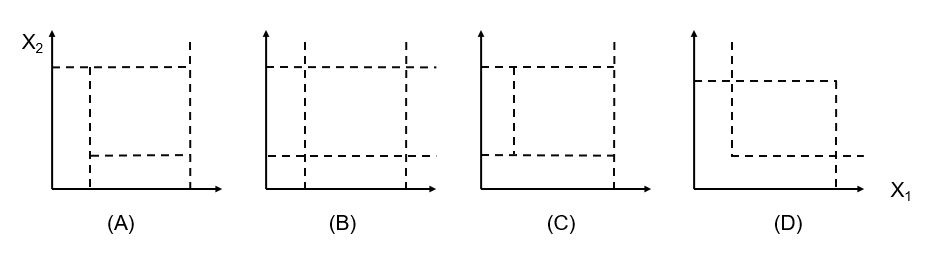

7. Create a new *distance* variable as follows: $D = \sqrt{ X_1^2 + X_2^2}$. Create a colored histogram for the distance variable; what is the best classification accuracy you can achieve by thresholding it?

For the remainder, consider the same data but with completely *random labels*, with equal probability.

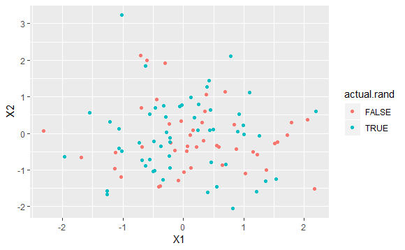

```r
set.seed(1234)
toy = toy %>%
  mutate( actual.rand = factor( sample( c(T,F), size = 100, replace = T ) ) )
ggplot(toy, aes(x = X1, y = X2, col = actual.rand) ) + geom_point()
```

8. What should be the accuracy of *any* classifier that tries to predict these random labels?
9. Report the accuracy of a) logistic regression, and b) classification tree, on the random labels. Which one has higher accuracy?